# cal_schools analysis

2024-04-10

# Overview

According to National Center of Education Statistics, “Higher levels of educational attainment are positively correlated with many outcomes, such as employment, earnings, and health.” (National Center for Education Statistics). The purpose of this analysis is to examine data publicly available through California Department of Education’s website (cde.ca.gov) to analyze where educational attainment gaps may exist, among different demographic groups.

```r
# import libraries

library(DBI)
library(RODBC)
library(odbc)
library(RPostgres)
suppressPackageStartupMessages(library(tidyverse))

# set theme
theme_set(theme_minimal())
```

# Part I

## Establish Connection with Database

In order to carry out the analysis, a connection will be established with Postgres cal_schools database. DBI, RPostgres, RODBC, odbc packages will be used for this process.

```r
# create connection object / establish connection with Postgres

con <- dbConnect(RPostgres::Postgres(),
                 dbname = 'cal_schools',
                 port = 5433,
                 user = 'postgres',
                 password = 'erikchris')
```

```r
# query database/ create table with high level stats (college going rate,
## enrollment, etc), along with school description info

school_stats <- dbGetQuery(con,
"WITH
  enr_school (cds_code, enr_total) AS
  (SELECT cds_code, SUM(enr_total) FROM enrollment
  GROUP BY cds_code),

  frmp_schools (cds_code, frmp_el) AS
  (SELECT cds_code, AVG(frpm_count::numeric/enr::numeric * 100)
  FROM fr_lunch
  GROUP BY cds_code),

  ell_schools(cds_code, ell_count) AS
  (SELECT cds_code, SUM(total_ell)
  FROM ell
  GROUP BY cds_code),

  cgr_schools (cds_code,hs_completers, enr_college, cgr) AS
  (SELECT cds_code, SUM(hs_completers), SUM(enr_college),
  AVG(enr_college::numeric/ hs_completers::numeric * 100)
  FROM college_gr
  WHERE reporting_cat = 'Total' AND completer_type = 'TA'
  GROUP BY cds_code),

  grad_schools (cds_code, grad_count) AS
  (SELECT cds_code, SUM(grad_count)
  FROM graduates
  WHERE reporting_cat = 'Total'
  GROUP BY cds_code),

  abs_schools (cds_code, unexc_abs_pct) AS
  (SELECT cds_code, AVG(unexc_absences_pct)
  FROM absents
  WHERE reporting_cat = 'Total'
  GROUP BY cds_code
  )

SELECT counties.county_code, county_name, schools.cds_code, district_name,
school_name, status_type, street, city, zip, phone, email, website, open_date,
close_date, charter, soc, soc_type, ed_ops_name, eil_name, gs_offered, virtual,
year_round, latitude, longitude, adm_email, last_update, district_code, enr_total,
frmp_el, ell_count, (ell_count::numeric/enr_total::numeric * 100) AS ell_pct,
unexc_abs_pct, grad_count, cgr
FROM schools
LEFT JOIN enr_school enr
USING(cds_code)
LEFT JOIN frmp_schools fr
ON fr.cds_code = enr.cds_code
LEFT JOIN ell_schools ell
ON fr.cds_code = ell.cds_code
LEFT JOIN cgr_schools cgr
ON ell.cds_code = cgr.cds_code
LEFT JOIN grad_schools gr
ON cgr.cds_code = gr.cds_code
LEFT JOIN abs_schools abs
ON gr.cds_code = abs.cds_code
JOIN counties
ON schools.county_code = counties.county_code;")
```

```r
# query database/ create table that has detailed information about college going
## rates

college_gr <- dbGetQuery(con, "SELECT ac_year, cds_code, co.county_code,
                         county_name, school_name, reporting_cat, completer_type,
                         hs_completers, enr_college, enr_instate, enr_oos,
                         not_enr_college, uc_enr, csu_enr, ccc_enr,
                         enr_instate_private, enr_oos_4yr, enr_oos_2yr
                         FROM college_gr cgr
                         LEFT JOIN schools s
                         USING(cds_code)
                         LEFT JOIN counties co
                         ON cgr.county_code = co.county_code
                         WHERE cds_code NOT IN (SELECT cds_code FROM schools
                         WHERE soc_type = 'Continuation High Schools') ;")
```

```r
# create new column in college stats ; cgr

college_gr <- college_gr |>
  mutate(cgr = (enr_college/hs_completers*100))
```

```r
# disconnect from database; move forward to analysis

dbDisconnect(con)
```

# Part II

## Exploratory Analysis

In this phase, high level summary statistics will be acquired to get information about tables and their respective variables. Additionally, histograms, density plots, and box plots will be created to visualize how distributions of college going rates differ among varying demographic groups. Additionally, scatter plots will be created to visualize the relationship between college going rates and other variables/ characteristics.

```r
# summary statistics of school_stats

summary(school_stats)
```

```
##  county_code        county_name          cds_code         district_name
##  Length:18335       Length:18335       Length:18335       Length:18335
##  Class :character   Class :character   Class :character   Class :character
##  Mode  :character   Mode  :character   Mode  :character   Mode  :character
##
##
##
##
##  school_name        status_type           street              city
##  Length:18335       Length:18335       Length:18335       Length:18335
##  Class :character   Class :pq_sts      Class :character   Class :character
##  Mode  :character   Mode  :character   Mode  :character   Mode  :character
##
##
##
##
##      zip               phone              email             website
##  Length:18335       Length:18335       Length:18335       Length:18335
##  Class :character   Class :character   Class :character   Class :character
##  Mode  :character   Mode  :character   Mode  :character   Mode  :character
##
##
##
##
##    open_date            close_date          charter            soc
##  Min.   :1850-07-01   Min.   :1980-07-01   Mode :logical   Length:18335
##  1st Qu.:1980-07-01   1st Qu.:1989-06-30   FALSE:14934     Class :character
##  Median :1980-07-01   Median :1994-06-03   TRUE :2007      Mode  :character
##  Mean   :1992-02-15   Mean   :1999-05-10   NA's :1394
##  3rd Qu.:2003-08-28   3rd Qu.:2010-06-17
##  Max.   :2069-09-01   Max.   :2024-01-05
##  NA's   :1394         NA's   :12048
##    soc_type         ed_ops_name          eil_name          gs_offered
##  Length:18335       Length:18335       Length:18335       Length:18335
##  Class :character   Class :character   Class :character   Class :character
##  Mode  :character   Mode  :character   Mode  :character   Mode  :character
##
##
##
##
```

[output cut: 17 more lines]

```
##  Min.   :  0.00   Min.   :   1   Min.   :  0.033   Min.   :  0.00
##  1st Qu.: 40.44   1st Qu.:  84   1st Qu.:  7.496   1st Qu.: 32.43
##  Median : 69.01   Median : 246   Median : 16.525   Median : 52.27
##  Mean   : 62.24   Mean   : 349   Mean   : 20.684   Mean   : 49.95
##  3rd Qu.: 86.16   3rd Qu.: 513   3rd Qu.: 30.326   3rd Qu.: 72.10
##  Max.   :100.00   Max.   :4738   Max.   :100.000   Max.   :100.00
##  NA's   :8429     NA's   :8642   NA's   :8642      NA's   :16145
##    grad_count         cgr
##  Min.   :    9   Min.   : 0.00
##  1st Qu.:  143   1st Qu.:32.05
##  Median :  399   Median :56.79
##  Mean   :  769   Mean   :52.80
##  3rd Qu.: 1326   3rd Qu.:71.97
##  Max.   : 4028   Max.   :96.04
##  NA's   :16143   NA's   :16142
```

```r
# summary statistics of school_stats

summary(college_gr)
```

```
##    ac_year            cds_code         county_code        county_name
##  Length:413135      Length:413135      Length:413135      Length:413135
##  Class :character   Class :character   Class :character   Class :character
##  Mode  :character   Mode  :character   Mode  :character   Mode  :character
##
##
##
##  school_name        reporting_cat      completer_type     hs_completers
##  Length:413135      Length:413135      Length:413135      Min.   :  11.00
##  Class :character   Class :character   Class :character   1st Qu.:  23.00
##  Mode  :character   Mode  :character   Mode  :character   Median :  51.00
##                                                           Mean   :  93.02
##                                                           3rd Qu.: 123.00
##                                                           Max.   :1134.00
##   enr_college      enr_instate        enr_oos        not_enr_college
##  Min.   :  0.00   Min.   :  0.00   Min.   :  0.000   Min.   :  0.00
##  1st Qu.: 12.00   1st Qu.: 11.00   1st Qu.:  0.000   1st Qu.:  8.00
##  Median : 30.00   Median : 28.00   Median :  2.000   Median : 17.00
##  Mean   : 61.14   Mean   : 55.21   Mean   :  5.928   Mean   : 31.88
##  3rd Qu.: 79.00   3rd Qu.: 73.00   3rd Qu.:  5.000   3rd Qu.: 39.00
##  Max.   :882.00   Max.   :825.00   Max.   :262.000   Max.   :647.00
##      uc_enr           csu_enr          ccc_enr       enr_instate_private
##  Min.   :  0.000   Min.   :  0.00   Min.   :  0.00   Min.   : 0.000
##  1st Qu.:  0.000   1st Qu.:  0.00   1st Qu.:  7.00   1st Qu.: 0.000
##  Median :  1.000   Median :  3.00   Median : 17.00   Median : 1.000
##  Mean   :  6.815   Mean   : 11.74   Mean   : 33.86   Mean   : 2.787
##  3rd Qu.:  8.000   3rd Qu.: 15.00   3rd Qu.: 45.00   3rd Qu.: 3.000
##  Max.   :286.000   Max.   :270.00   Max.   :459.00   Max.   :93.000
##   enr_oos_4yr       enr_oos_2yr           cgr
##  Min.   :  0.000   Min.   : 0.0000   Min.   :  0.00
##  1st Qu.:  0.000   1st Qu.: 0.0000   1st Qu.: 45.24
##  Median :  1.000   Median : 0.0000   Median : 64.06
##  Mean   :  5.465   Mean   : 0.4624   Mean   : 61.54
##  3rd Qu.:  4.000   3rd Qu.: 1.0000   3rd Qu.: 80.65
##  Max.   :259.000   Max.   :16.0000   Max.   :100.00
```

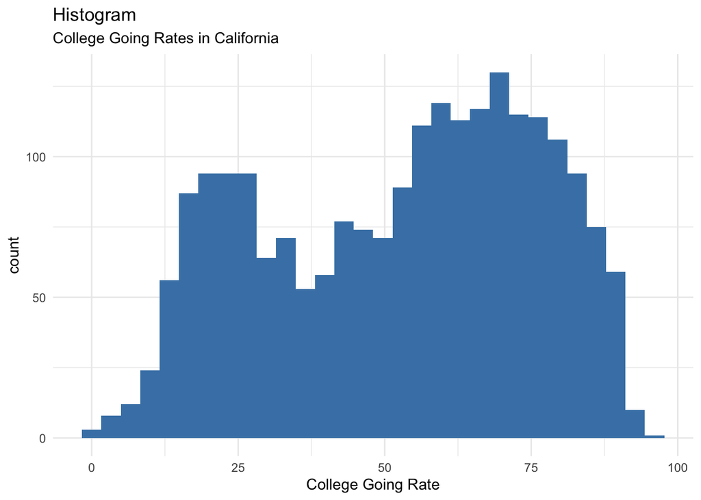

```r
# histogram of college going rate

ggplot(school_stats, aes(cgr))+
  geom_histogram(fill = 'steelblue')+
  labs(x = 'College Going Rate',
  title = 'Histogram',
  subtitle = 'College Going Rates in California')
```

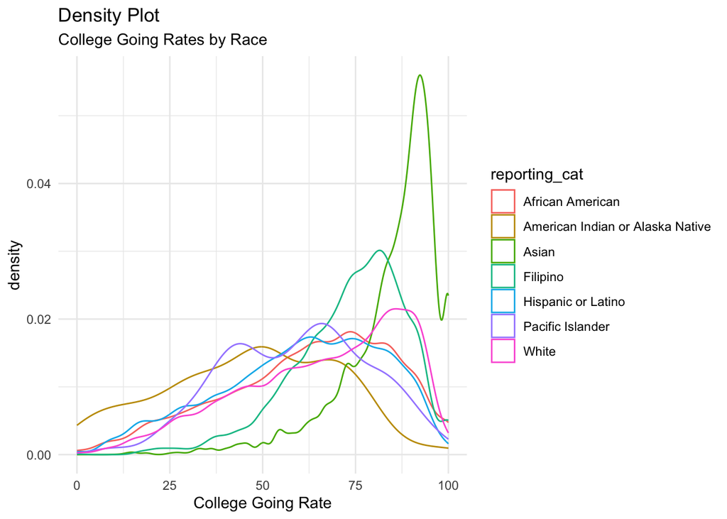

```r
# density plots of college going rates grouped by demographic info

college_gr |>
  filter(reporting_cat %in% c('African American', 'Filipino', 'Pacific Islander', 'American Indian or Alaska Native',
                              'Asian', 'Hispanic or Latino', 'White'))|>
  ggplot(aes(cgr, color = reporting_cat ))+
  geom_density()+
  labs(x = 'College Going Rate',
       title = "Density Plot",
       subtitle = 'College Going Rates by Race')
```

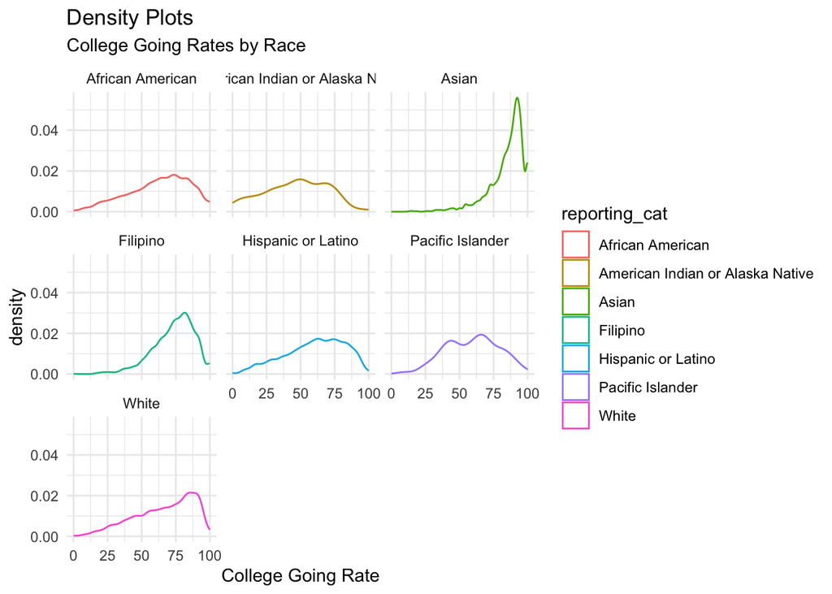

```r
## multi-facet density plot to see each distribution more clearly

college_gr |>
  filter(reporting_cat %in% c('African American', 'Filipino', 'Pacific Islander', 'American Indian or Alaska Native', 'Asian', 'Hispanic or Latino', 'White'))|>
  ggplot(aes(cgr, color = reporting_cat ))+
  geom_density()+
  facet_wrap(~reporting_cat)+
  labs(x = 'College Going Rate',
       title = 'Density Plots',
       subtitle = 'College Going Rates by Race')
```

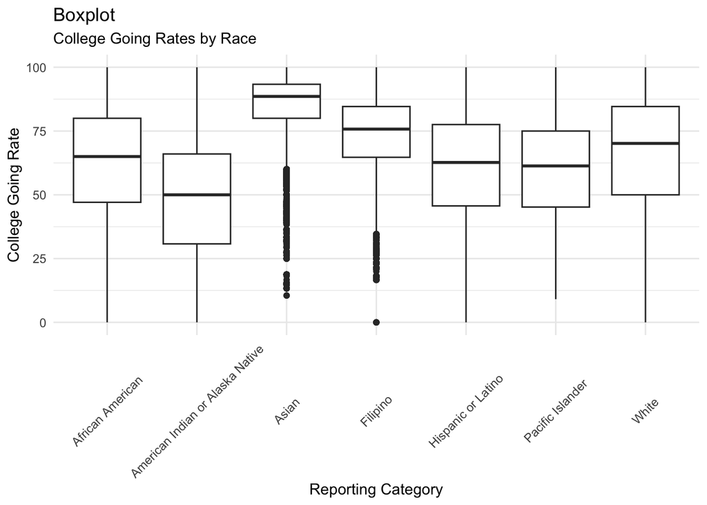

```r
# box plots of college going rate grouped by demographic info

college_gr |>
  filter(reporting_cat %in% c('African American', 'Filipino', 'Pacific Islander', 'American Indian or Alaska Native',
                              'Asian', 'Hispanic or Latino', 'White'))|>
  ggplot( aes(reporting_cat, cgr))+
  geom_boxplot()+
  theme(axis.text.x = element_text(angle = 45, vjust = 0.5))+
  labs(x = 'Reporting Category',
       y = 'College Going Rate',
       title = 'Boxplot',
       subtitle = 'College Going Rates by Race')
```

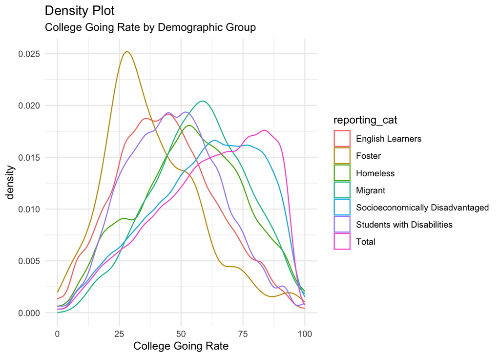

```r
# density plots of college going rates grouped by additional demographic characteristics (ell, socioeconomic, etc)

college_gr |>
  filter(reporting_cat %in% c('Students with Disabilities', 'Total', 'Homeless',
         'Socioeconomically Disadvantaged', 'Migrant', 'Foster', 'English Learners', 'Total'))|>
  ggplot(aes(cgr, color = reporting_cat))+
  geom_density()+
  labs(x = 'College Going Rate',
       title = 'Density Plot',
       subtitle = 'College Going Rate by Demographic Group')
```

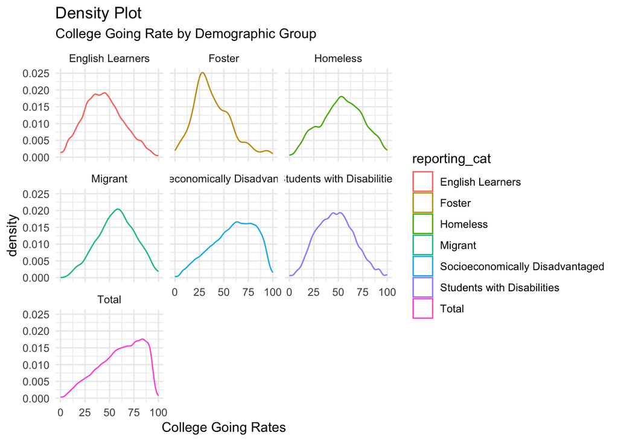

```r
## multi-facet density plots to see each distribution more clearly

college_gr |>
  filter(reporting_cat %in% c('Students with Disabilities', 'Total', 'Homeless',
         'Socioeconomically Disadvantaged', 'Migrant', 'Foster', 'English Learners', 'Total')) |>
  ggplot(aes(cgr, color = reporting_cat ))+
  geom_density()+
  facet_wrap(~reporting_cat)+
  labs(x= 'College Going Rates',
        title = 'Density Plot',
        subtitle = 'College Going Rate by Demographic Group')
```

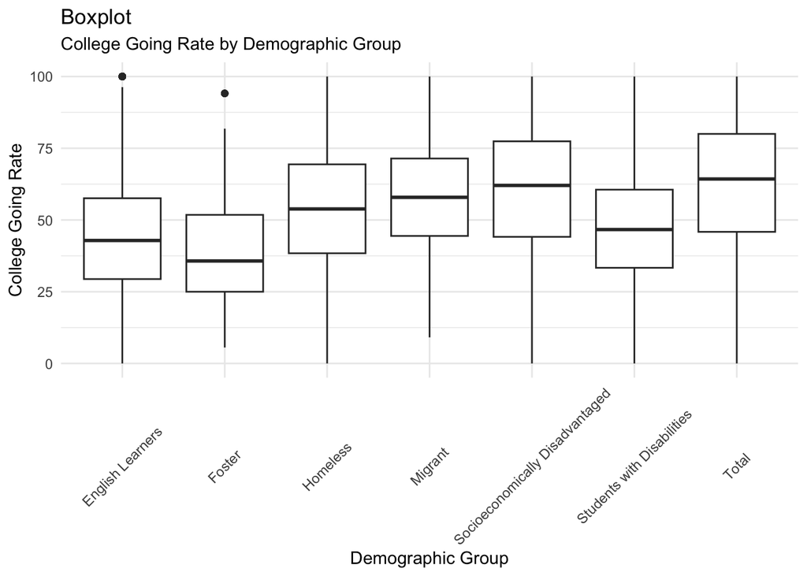

```r
# box plots grouped by additional demographic info

college_gr |>
  filter(reporting_cat %in% c('Students with Disabilities', 'Total', 'Homeless',
         'Socioeconomically Disadvantaged', 'Migrant', 'Foster', 'English Learners', 'Total'))|>
  ggplot(aes(reporting_cat, cgr))+
  geom_boxplot()+
  theme(axis.text.x = element_text(angle = 45, vjust = 0.5))+
  labs(x = 'Demographic Group',
       y = 'College Going Rate',
       title = 'Boxplot',
       subtitle = 'College Going Rate by Demographic Group')
```

```r
# create df to check correlations

cgr_cor <- school_stats |>
  select(frmp_el, unexc_abs_pct, ell_pct, cgr)

## correlations for frmp_el, unexc_abs_pct, ell_pct, and cgr

cor(cgr_cor, use='complete.obs')
```

```
##                  frmp_el unexc_abs_pct    ell_pct        cgr
## frmp_el        1.0000000     0.3996658  0.5304031 -0.4867759
## unexc_abs_pct  0.3996658     1.0000000  0.3407536 -0.1674253
## ell_pct        0.5304031     0.3407536  1.0000000 -0.2950742
## cgr           -0.4867759    -0.1674253 -0.2950742  1.0000000
```

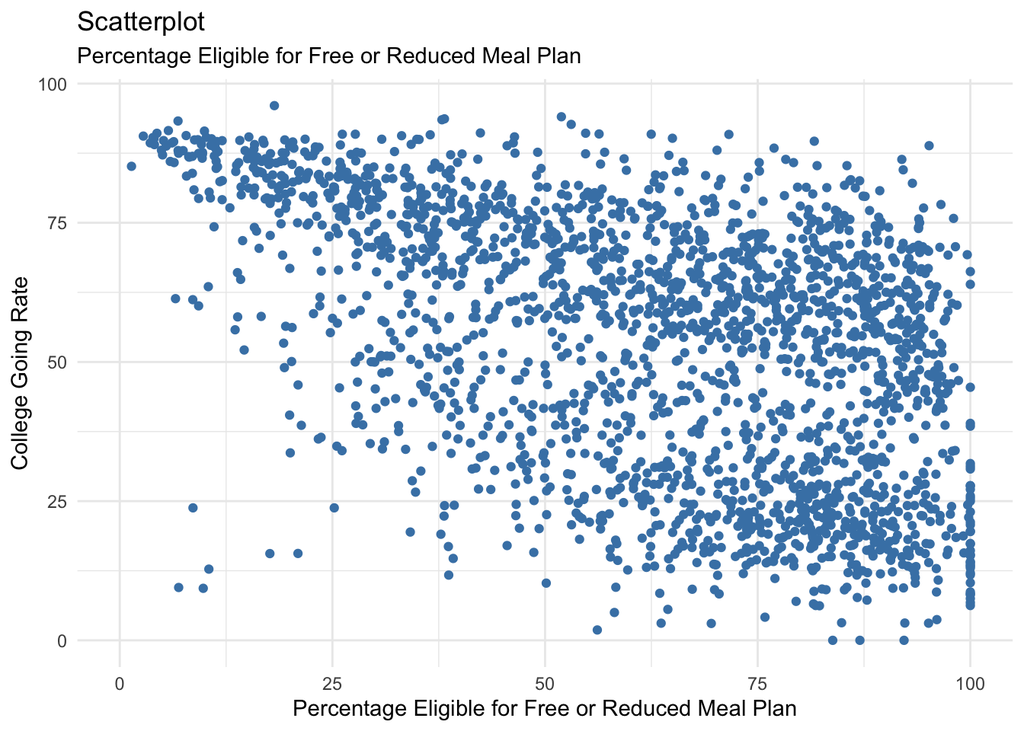

```r
# scatter plots

## college going rate and reduced lunch percent eligible
ggplot(school_stats, aes(frmp_el, cgr))+
  geom_point(color = 'steelblue')+
  labs(x = 'Percentage Eligible for Free or Reduced Meal Plan',
       y = 'College Going Rate',
       title = 'Scatterplot',
       subtitle = 'Percentage Eligible for Free or Reduced Meal Plan')
```

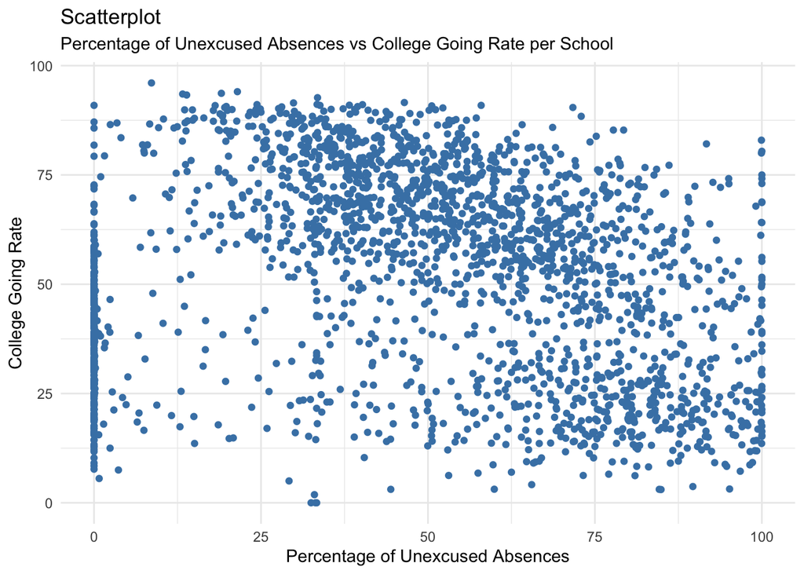

```r
## college going rate and unexcused absence percent
ggplot(school_stats,  aes(unexc_abs_pct, cgr))+
  geom_point(color = 'steelblue')+
  labs(x = 'Percentage of Unexcused Absences',
       y = 'College Going Rate',
       title = 'Scatterplot',
       subtitle = 'Percentage of Unexcused Absences vs College Going Rate per School')
```

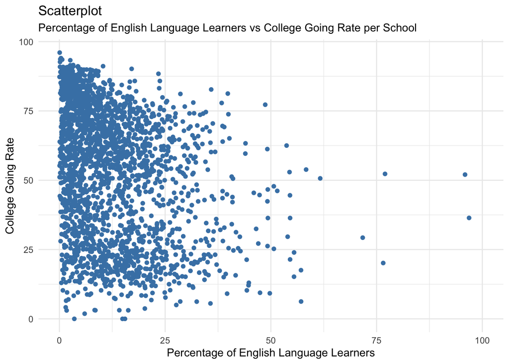

```r
## college going rate and percent english language learners
ggplot(school_stats, aes(ell_pct, cgr))+
  geom_point(color = 'steelblue')+
  labs(x = 'Percentage of English Language Learners',
       y = 'College Going Rate',
       title = 'Scatterplot',
       subtitle = 'Percentage of English Language Learners vs College Going Rate per School')
```

# Part III

## Analysis and Visualizations

In the exploratory analysis, it was found that college going rates differ among different demographic groups. Additionally, a number of different factors are correlated with college going rates. This part of the analysis will utilize tidyverse functions to identify groups that have lower than average college going rates. ggplot2 will also be utilized to visualize instances where educational attainment gaps exist.

```r
# lowest to highest college going rate by county

school_stats |>
  group_by(county_name) |>
  summarise(cgr = round(mean(cgr, na.rm = TRUE), 2)) |>
  arrange(cgr)
```

| county_name | cgr |
| --- | --- |
| Del Norte | 27.50 |
| Inyo | 31.69 |
| Mariposa | 34.26 |
| Lassen | 35.52 |
| Mendocino | 36.05 |
| Calaveras | 37.76 |
| Lake | 38.44 |
| Tehama | 38.75 |
| San Benito | 39.64 |
| Kern | 40.12 |

[output cut: 48 more lines]

```r
# lowest to highest college going rate by county/district

school_stats |>
  group_by(county_name, district_name) |>
  summarise(cgr = round(mean(cgr, na.rm = TRUE), 2), .groups = 'drop') |>
  arrange(cgr) |>
  head(10)
```

| county_name | district_name | cgr |
| --- | --- | --- |
| Santa Barbara | Santa Barbara County Office of Education | 14.09 |
| Lassen | Susanville Elementary | 14.36 |
| Amador | Amador County Office of Education | 14.71 |
| Mendocino | Round Valley Unified | 16.46 |
| San Bernardino | Baker Valley Unified | 16.67 |
| Stanislaus | Stanislaus County Office of Education | 16.87 |
| Solano | Solano County Office of Education | 17.42 |
| Mono | Mono County Office of Education | 17.55 |
| San Benito | San Benito High | 19.56 |
| San Bernardino | Adelanto Elementary | 19.66 |

```r
# prepare data for visualization

## get location data for California and its counties
cal_counties <- map_data('county')
cal_counties <- cal_counties|>
  filter(region == 'california')

## get college going rates by county
cgr_counties <- school_stats |>
  group_by(county_name) |>
  summarise(cgr = round(mean(cgr, na.rm= TRUE), 2)) |>
  arrange(desc(cgr))

## change county_name to lowercase for merging purposes
cgr_counties$county_name <- tolower(cgr_counties$county_name)


# merge county location data with college going rate for plotting
cgr_counties <- left_join(cal_counties, cgr_counties, by = c('subregion' = 'county_name'))
```

```r
# get 5 counties with the lowest college going rates
## will be used as labels for visualization

cgr_2 <- cgr_counties |>
  group_by(subregion) |>
  summarise(long = min(long),
            lat = min(lat),
            cgr = mean(cgr))|>
  arrange(cgr)|>
  head(5)
```

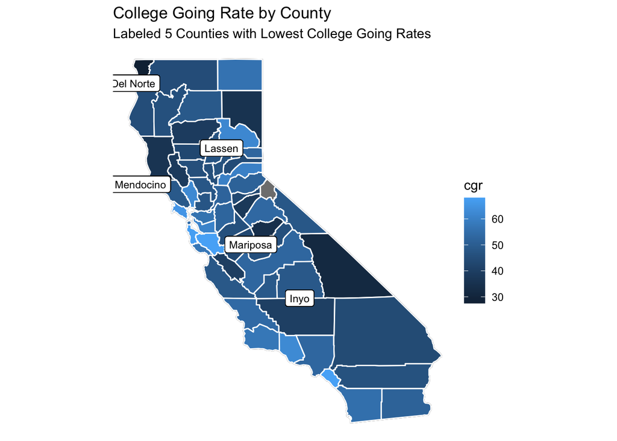

```r
# visualize map of California with color density to reflect college going rate by county

ggplot(cal_counties, mapping = aes(x=long, y=lat, group=group)) +
  coord_quickmap()+
  geom_polygon(color = 'black', fill='white')+
  geom_polygon(data = cgr_counties, aes(fill = cgr), color = 'white')+
  theme_void()+
  # label 5 counties with lowest college going rates
  geom_label(aes(x = -124.2344, y=41.39047, label = 'Del Norte'), size = 3)+
  geom_label(aes(x = -118.7799, y=35.78695, label = 'Inyo'), size = 3)+
  geom_label(aes(x = -121.3410, y=39.70024, label = 'Lassen'), size = 3)+
  geom_label(aes(x = -120.3842, y=37.18496, label = 'Mariposa'), size = 3)+
  geom_label(aes(x = -123.9995, y=38.75486, label = 'Mendocino'), size = 3)+
  labs(title = 'College Going Rate by County',
       subtitle = 'Labeled 5 Counties with Lowest College Going Rates')
```

```r
# get college going rates grouped by demographic info

college_gr |>
  filter(reporting_cat %in% c('Asian', 'White', 'Filipino', 'Hispanic or Latino',
                              'African American', 'American Indian or Alaska Native',
                              'Pacific Islander')) |>
  group_by(ac_year, reporting_cat) |>
  summarise(cgr = round(mean(cgr, na.rm = TRUE), 2), .groups = 'drop') |>
  arrange(cgr)
```

| ac_year | reporting_cat | cgr |
| --- | --- | --- |
| 2020-21 | American Indian or Alaska Native | 38.21 |
| 2019-20 | American Indian or Alaska Native | 43.29 |
| 2017-18 | American Indian or Alaska Native | 44.77 |
| 2018-19 | American Indian or Alaska Native | 52.41 |
| 2019-20 | Pacific Islander | 54.24 |
| 2020-21 | Pacific Islander | 54.98 |
| 2020-21 | Hispanic or Latino | 56.94 |
| 2020-21 | African American | 57.25 |
| 2019-20 | African American | 58.35 |
| 2019-20 | Hispanic or Latino | 58.44 |

[output cut: 18 more lines]

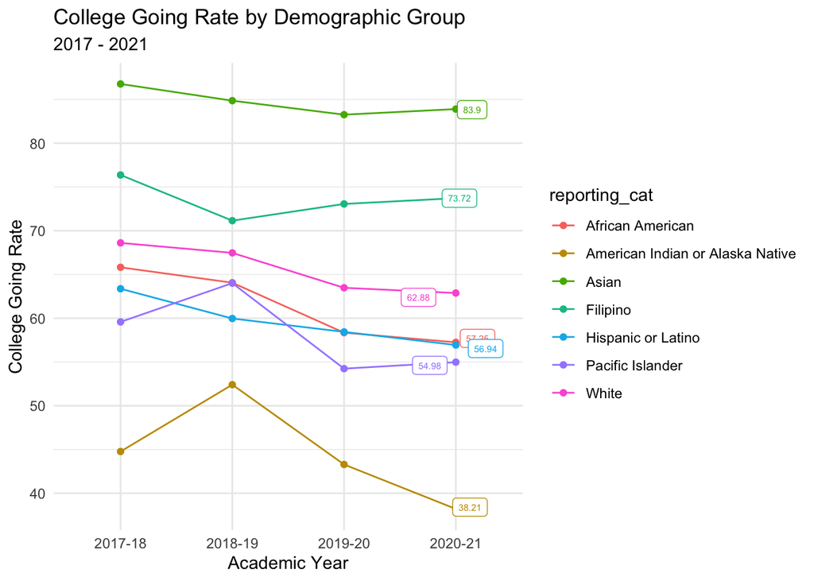

```r
# create separate data frame for cgr/demographic group for plotting

cgr_dems <- college_gr |>
  group_by(ac_year, reporting_cat) |>
  summarise(cgr = round(mean(cgr), 2), .groups = 'drop') |>
  filter(reporting_cat %in% c('Asian', 'White', 'Filipino', 'Hispanic or Latino',
                              'African American', 'American Indian or Alaska Native',
                              'Pacific Islander'))

# create a separate object for labels
cgr_ends <- cgr_dems |>
  filter(ac_year == '2020-21')


# plot line graph
ggplot(cgr_dems, aes(ac_year, cgr, group= reporting_cat, color = reporting_cat))+
  geom_line()+
  geom_point()+
  geom_label(data = cgr_ends, aes(label = cgr), size = 2, position = position_jitter(width = 0.5, height = 0.5),
             show.legend = F)+
  labs(x = 'Academic Year',
       y = 'College Going Rate',
       title = "College Going Rate by Demographic Group",
       subtitle = '2017 - 2021')
```

```r
# college going rate grouped by county & demographic group

college_gr |>
  group_by(county_name, reporting_cat) |>
  summarise (cgr = mean(cgr), .groups = 'drop') |>
  arrange(cgr)
```

| county_name | reporting_cat | cgr |
| --- | --- | --- |
| Del Norte | Two or More Races | 0.000000 |
| Colusa | English Learners | 9.090909 |
| Mono | Homeless | 9.090909 |
| Nevada | English Learners | 11.619660 |
| Inyo | English Learners | 16.519302 |
| Inyo | Foster | 16.666667 |
| Mono | English Learners | 18.493016 |
| Glenn | English Learners | 18.703704 |
| Nevada | African American | 19.329353 |
| Humboldt | Homeless | 20.347708 |

[output cut: 705 more lines]

```r
# filter df for needed demographic groups
cgr_dems2 <- college_gr |>
  filter(reporting_cat %in% c('English Learners', 'Foster', 'Homeless', 'Migrant', 'Students with Disabilities')) |>
  group_by(ac_year, reporting_cat) |>
  summarise(total = sum(enr_college), .groups = 'drop')

# create df with aggregate info/ total college enrollment per year
cgr_years <- college_gr |>
  filter(reporting_cat == 'Total') |>
  group_by(ac_year) |>
  summarise(acc = sum(enr_college))

# join dfs for plotting
cgr_pcts <- left_join(cgr_dems2, cgr_years, by = join_by(ac_year))

# get percentage of demographic group enrolling in college
cgr_pcts <- cgr_pcts |>
  mutate (pct = total/acc * 100)
```

Out of all student enrolled in college, what percentage were in the following demographic groups?:

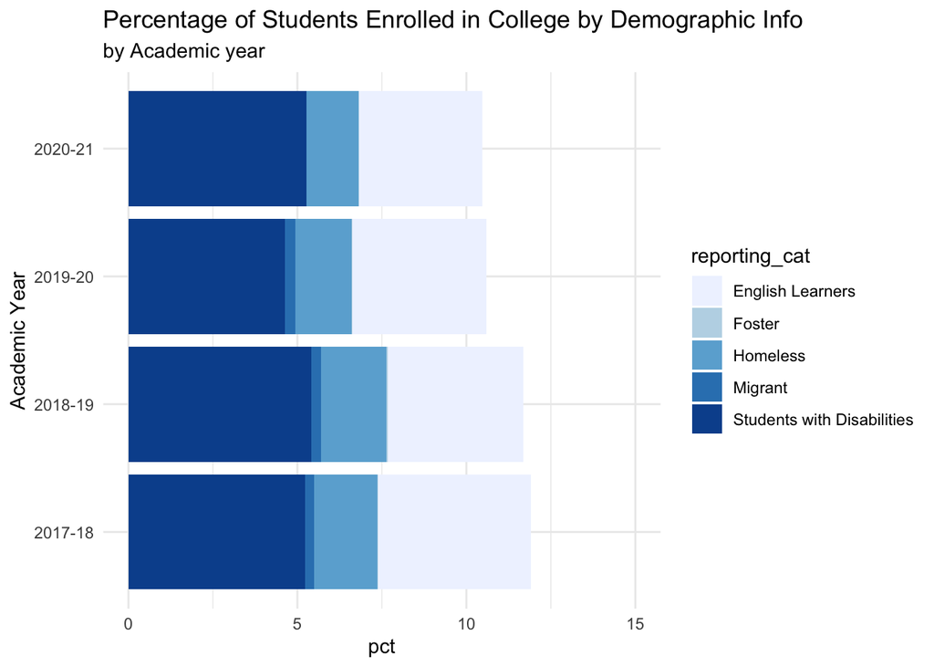

```r
# plot percentage of certain demographics enrolled in college out of all students enrolled in college

ggplot(cgr_pcts, aes(ac_year, pct, fill = reporting_cat))+
  geom_bar(position = 'stack', stat = 'identity')+
  scale_y_continuous(name = 'pct', limits = c(0, 15))+
  scale_fill_brewer()+
  labs(x = 'Academic Year',
       title = 'Percentage of Students Enrolled in College by Demographic Info',
       subtitle = 'by Academic year')+
  coord_flip()
```